# R Notebook

# Time Series Analysis on S&P 500

```r
sp500daily=read.csv("https://raw.githubusercontent.com/katariyj/Time-Series-Forecasting-S-P-500/master/GSPCdaily26Feb2018.csv",header=T)
head(sp500daily)
```

|  | Date | Open | High | Low | Close | Adj.Close | Volume |
| --- | --- | --- | --- | --- | --- | --- | --- |
| 1 | 2014-02-26 | 1845.79 | 1852.65 | 1840.66 | 1845.16 | 1845.16 | 3716730000 |
| 2 | 2014-02-27 | 1844.90 | 1854.53 | 1841.13 | 1854.29 | 1854.29 | 3547460000 |
| 3 | 2014-02-28 | 1855.12 | 1867.92 | 1847.67 | 1859.45 | 1859.45 | 3917450000 |
| 4 | 2014-03-03 | 1857.68 | 1857.68 | 1834.44 | 1845.73 | 1845.73 | 3428220000 |
| 5 | 2014-03-04 | 1849.23 | 1876.23 | 1849.23 | 1873.91 | 1873.91 | 3765770000 |
| 6 | 2014-03-05 | 1874.05 | 1876.53 | 1871.11 | 1873.81 | 1873.81 | 3392990000 |

```r
tail(sp500daily)
```

|  | Date | Open | High | Low | Close | Adj.Close | Volume |
| --- | --- | --- | --- | --- | --- | --- | --- |
| 1002 | 2018-02-15 | 2713.46 | 2731.51 | 2689.82 | 2731.20 | 2731.20 | 3684910000 |
| 1003 | 2018-02-16 | 2727.14 | 2754.42 | 2725.11 | 2732.22 | 2732.22 | 3637460000 |
| 1004 | 2018-02-20 | 2722.99 | 2737.60 | 2706.76 | 2716.26 | 2716.26 | 3627610000 |
| 1005 | 2018-02-21 | 2720.53 | 2747.75 | 2701.29 | 2701.33 | 2701.33 | 3779400000 |
| 1006 | 2018-02-22 | 2710.42 | 2731.26 | 2697.77 | 2703.96 | 2703.96 | 3701270000 |
| 1007 | 2018-02-23 | 2715.80 | 2747.76 | 2713.74 | 2747.30 | 2747.30 | 3189190000 |

BASIC EDA Head() - This will return the first n observations of the dataset. Default is 6 Tail() - This will return the last n observations of the dataset. Default is 6 Summary() - This will return the summary of the statistics like min, median, max, quartiles for each column of the dataset. Count returns missing value if any. Dim() - This will return the dimensions of the data frame like the number of rows and number of columns in the dataset. The output is a vector. Hist() - This will return a bar plot in which each bar represents the frequency of cases for a range of values Str() - returns the classes of each of the columns whether it is numerical or categorical data. Names() - This will return the column headers.

BASIC EDA OF SP500

```r
head(sp500daily)
```

|  | Date | Open | High | Low | Close | Adj.Close | Volume |
| --- | --- | --- | --- | --- | --- | --- | --- |
| 1 | 2014-02-26 | 1845.79 | 1852.65 | 1840.66 | 1845.16 | 1845.16 | 3716730000 |
| 2 | 2014-02-27 | 1844.90 | 1854.53 | 1841.13 | 1854.29 | 1854.29 | 3547460000 |
| 3 | 2014-02-28 | 1855.12 | 1867.92 | 1847.67 | 1859.45 | 1859.45 | 3917450000 |
| 4 | 2014-03-03 | 1857.68 | 1857.68 | 1834.44 | 1845.73 | 1845.73 | 3428220000 |
| 5 | 2014-03-04 | 1849.23 | 1876.23 | 1849.23 | 1873.91 | 1873.91 | 3765770000 |
| 6 | 2014-03-05 | 1874.05 | 1876.53 | 1871.11 | 1873.81 | 1873.81 | 3392990000 |

```r
tail(sp500daily)
```

|  | Date | Open | High | Low | Close | Adj.Close | Volume |
| --- | --- | --- | --- | --- | --- | --- | --- |
| 1002 | 2018-02-15 | 2713.46 | 2731.51 | 2689.82 | 2731.20 | 2731.20 | 3684910000 |
| 1003 | 2018-02-16 | 2727.14 | 2754.42 | 2725.11 | 2732.22 | 2732.22 | 3637460000 |
| 1004 | 2018-02-20 | 2722.99 | 2737.60 | 2706.76 | 2716.26 | 2716.26 | 3627610000 |
| 1005 | 2018-02-21 | 2720.53 | 2747.75 | 2701.29 | 2701.33 | 2701.33 | 3779400000 |
| 1006 | 2018-02-22 | 2710.42 | 2731.26 | 2697.77 | 2703.96 | 2703.96 | 3701270000 |
| 1007 | 2018-02-23 | 2715.80 | 2747.76 | 2713.74 | 2747.30 | 2747.30 | 3189190000 |

```r
summary(sp500daily)
```

```
         Date           Open           High           Low           Close        Adj.Close
 2014-02-26:   1   Min.   :1818   Min.   :1834   Min.   :1810   Min.   :1816   Min.   :1816
 2014-02-27:   1   1st Qu.:2003   1st Qu.:2017   1st Qu.:1992   1st Qu.:2002   1st Qu.:2002
 2014-02-28:   1   Median :2097   Median :2103   Median :2086   Median :2097   Median :2097
 2014-03-03:   1   Mean   :2168   Mean   :2176   Mean   :2158   Mean   :2168   Mean   :2168
 2014-03-04:   1   3rd Qu.:2343   3rd Qu.:2351   3rd Qu.:2335   3rd Qu.:2344   3rd Qu.:2344
 2014-03-05:   1   Max.   :2867   Max.   :2873   Max.   :2851   Max.   :2873   Max.   :2873
 (Other)   :1001
     Volume
 Min.   :1.350e+09
 1st Qu.:3.171e+09
 Median :3.502e+09
 Mean   :3.593e+09
 3rd Qu.:3.903e+09
 Max.   :7.597e+09
```

```r
dim(sp500daily)
```

```
[1] 1007    7
```

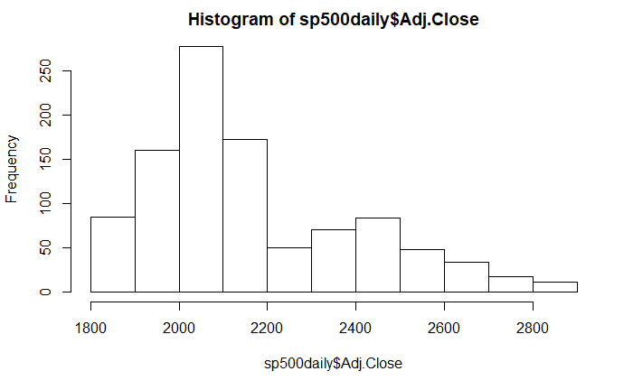

```r
hist(sp500daily$Adj.Close)
```

```r
str(sp500daily)
```

```
'data.frame':   1007 obs. of  7 variables:
 $ Date     : Factor w/ 1007 levels "2014-02-26","2014-02-27",..: 1 2 3 4 5 6 7 8 9 10 ...
 $ Open     : num  1846 1845 1855 1858 1849 ...
 $ High     : num  1853 1855 1868 1858 1876 ...
 $ Low      : num  1841 1841 1848 1834 1849 ...
 $ Close    : num  1845 1854 1859 1846 1874 ...
 $ Adj.Close: num  1845 1854 1859 1846 1874 ...
 $ Volume   : num  3.72e+09 3.55e+09 3.92e+09 3.43e+09 3.77e+09 ...
```

```r
names(sp500daily)
```

```
[1] "Date"      "Open"      "High"      "Low"       "Close"     "Adj.Close" "Volume"
```

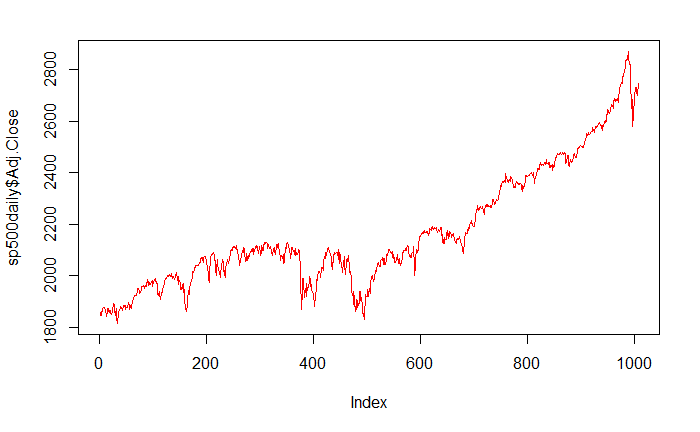

```r
plot(sp500daily$Adj.Close, type = "l",col="red")
```

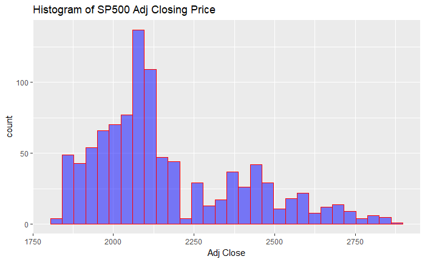

```r
# Advance EDA
library(ggplot2)
qplot(sp500daily$Adj.Close, fill = I("blue"), alpha = I(.5), col= I("red"),xlab = "Adj Close",  main="Histogram of SP500 Adj Closing Price", bins = 30)
```

```r
install.packages("ggfortify")
```

```
Error in install.packages : Updating loaded packages
```

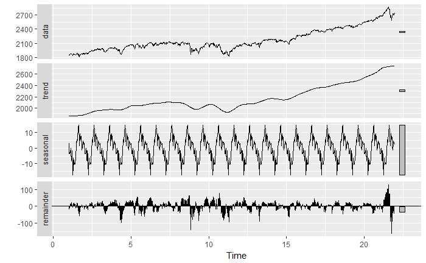

```r
library(ggfortify)
library(stats)
library(forecast)
sp500close = ts(sp500daily$Adj.Close, frequency = 48)
autoplot(stl(sp500close, s.window = 'periodic'), ts.colour = 'blue')
```

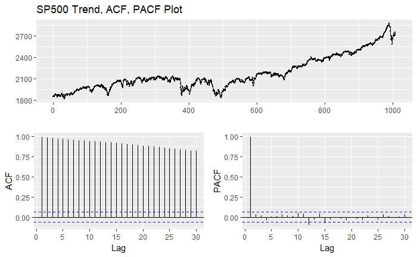

```r
ggtsdisplay(sp500daily$Adj.Close, main = "SP500 Trend, ACF, PACF Plot")
```

Advance EDA For Daily Returns for SP500

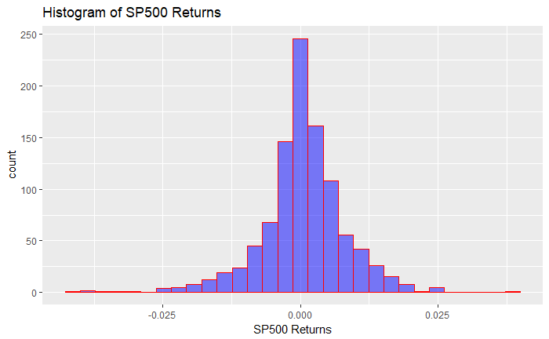

```r
sp500_price = sp500daily$Adj.Close
sp500returns =diff(sp500_price)/sp500_price[-length(sp500_price)]
qplot(sp500returns, fill = I("blue"), alpha = I(.5), col= I("red"),xlab = "SP500 Returns",  main="Histogram of SP500 Returns", bins = 30)
```

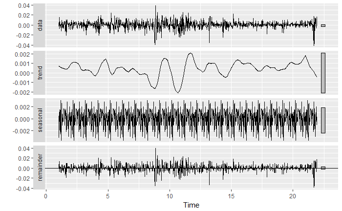

```r
sp500_returns = ts(sp500returns, frequency = 48)
autoplot(stl(sp500_returns, s.window = 'periodic'), ts.colour = 'blue')
```

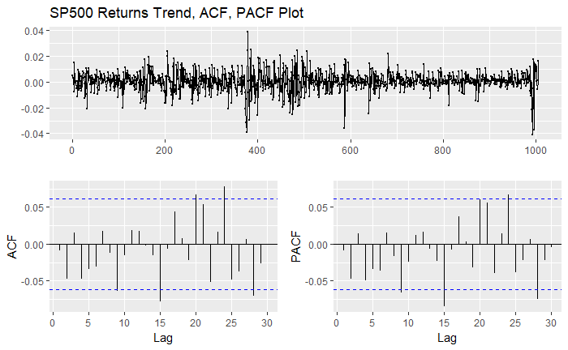

```r
ggtsdisplay(sp500returns, main = "SP500 Returns Trend, ACF, PACF Plot")
```

Transformations and EDA - LOG Returns of SP500

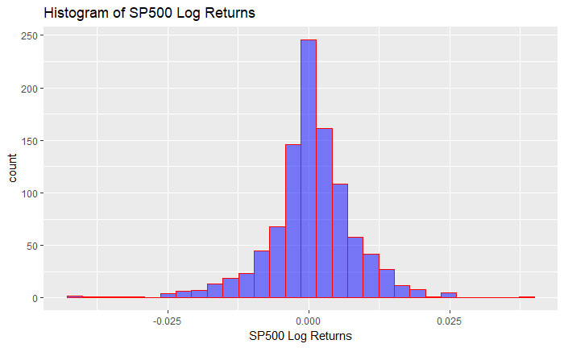

```r
sp500_logreturns1=diff(log(sp500_price))
qplot(sp500_logreturns1, fill = I("blue"), alpha = I(.5), col= I("red"),xlab = "SP500 Log Returns",  main="Histogram of SP500 Log Returns", bins = 30)
```

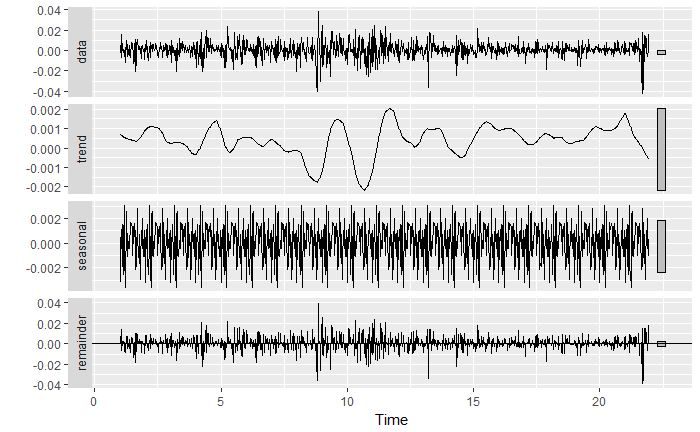

```r
sp500_logreturns2 = ts(sp500_logreturns1, frequency = 48)
autoplot(stl(sp500_logreturns2, s.window = 'periodic'), ts.colour = 'blue')
```

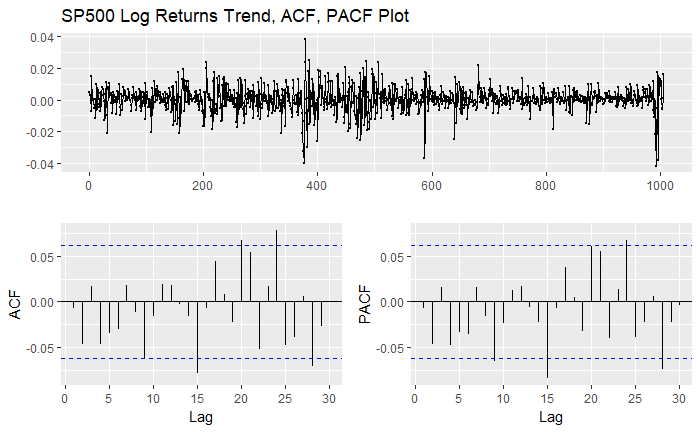

```r
ggtsdisplay(sp500_logreturns1, main = "SP500 Log Returns Trend, ACF, PACF Plot")
```

Compare Histogram of daily returns and Log returns

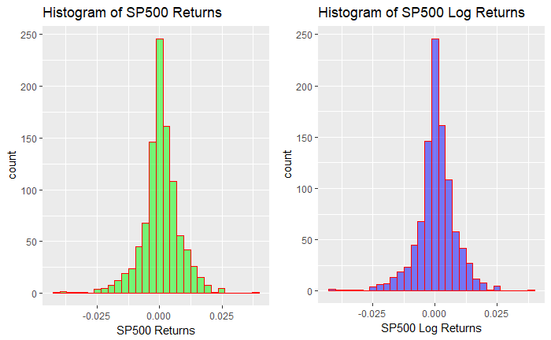

```r
require(gridExtra)
Daily_Returns = qplot(sp500returns, fill = I("green"), alpha = I(.5), col= I("red"),xlab = "SP500 Returns",  main="Histogram of SP500 Returns", bins = 30)
Log_Returns=qplot(sp500_logreturns1, fill = I("blue"), alpha = I(.5), col= I("red"),xlab = "SP500 Log Returns",  main="Histogram of SP500 Log Returns", bins = 30)
grid.arrange(Daily_Returns, Log_Returns, ncol=2)
```

Check Stats of the data

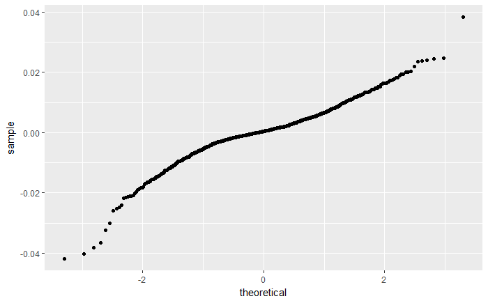

```r
ggplot(data.frame(sp500_logreturns1), aes(sample=sp500_logreturns1))+stat_qq()
```

```r
library(fBasics) ## This loads the package fBasic
basicStats(sp500returns)
```

|  | sp500returns |
| --- | --- |
| nobs | 1006.000000 |
| NAs | 0.000000 |
| Minimum | -0.040979 |
| Maximum | 0.039034 |
| 1. Quartile | -0.002727 |
| 3. Quartile | 0.004405 |
| Mean | 0.000426 |
| Median | 0.000452 |
| Sum | 0.428974 |
| SE Mean | 0.000247 |

[output cut: 6 more lines]

```r
basicStats(sp500_logreturns1)
```

|  | sp500_logreturns1 |
| --- | --- |
| nobs | 1006.000000 |
| NAs | 0.000000 |
| Minimum | -0.041843 |
| Maximum | 0.038291 |
| 1. Quartile | -0.002731 |
| 3. Quartile | 0.004396 |
| Mean | 0.000396 |
| Median | 0.000452 |
| Sum | 0.398053 |
| SE Mean | 0.000247 |

[output cut: 6 more lines]

```r
t.test(sp500_logreturns1)
```

```
    One Sample t-test

data:  sp500_logreturns1
t = 1.601, df = 1005, p-value = 0.1097
alternative hypothesis: true mean is not equal to 0
95 percent confidence interval:
 -8.930867e-05  8.806658e-04
sample estimates:
   mean of x
0.0003956785
```

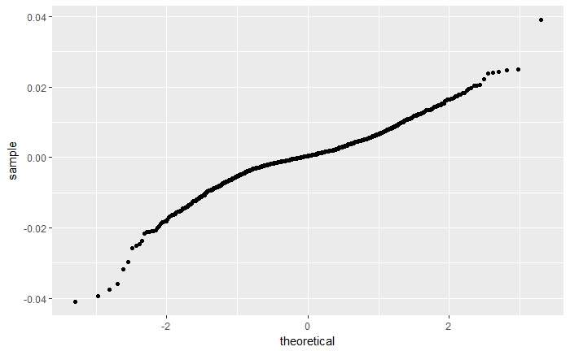

```r
ggplot(data.frame(sp500returns), aes(sample=sp500returns))+stat_qq()
```

```r
t.test(sp500returns)
```

```
    One Sample t-test

data:  sp500returns
t = 1.7285, df = 1005, p-value = 0.0842
alternative hypothesis: true mean is not equal to 0
95 percent confidence interval:
 -5.767179e-05  9.105032e-04
sample estimates:
   mean of x
0.0004264157
```

```r
## Normality tests
normalTest(sp500returns,method="jb")
```

```
Title:
 Jarque - Bera Normalality Test

Test Results:
  STATISTIC:
    X-squared: 638.1122
  P VALUE:
    Asymptotic p Value: < 2.2e-16

Description:
 Wed May 02 02:33:39 2018 by user: Jai Katariya
```

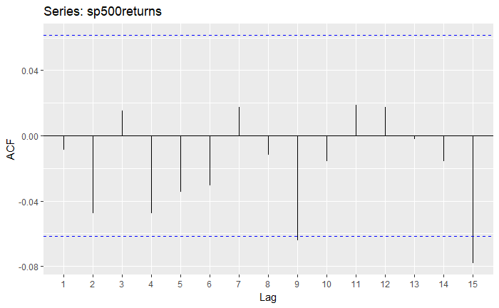

```r
autoplot(acf(sp500returns,lag=15, plot = FALSE)) # Obtain the ACF plot
```

```r
##Independence tests
Box.test(sp500returns,lag=10)
```

```
    Box-Pierce test

data:  sp500returns
X-squared = 11.848, df = 10, p-value = 0.2954
```

```r
install.packages("ggfortify")
Box.test(sp500returns,lag=10,type="Ljung")
```

```
    Box-Ljung test

data:  sp500returns
X-squared = 11.941, df = 10, p-value = 0.289
```

Model1 - AR Model

```r
model1 = ar(sp500returns, method = 'mle')
model1
```

```
Call:
ar(x = sp500returns, method = "mle")


Order selected 0  sigma^2 estimated as  6.116e-05
```

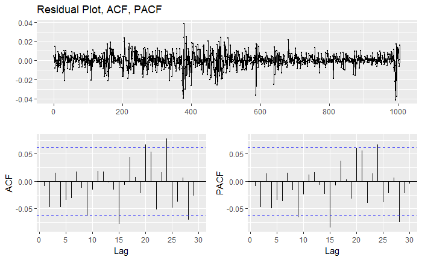

```r
ggtsdisplay(model1$resid, main= "Residual Plot, ACF, PACF")
```

Model 2

```r
model2=arima(x=sp500returns,order=c(0,0,1))
model2
```

```
Call:
arima(x = sp500returns, order = c(0, 0, 1))

Coefficients:
          ma1  intercept
      -0.0098      4e-04
s.e.   0.0332      2e-04

sigma^2 estimated as 6.116e-05:  log likelihood = 3452.7,  aic = -6899.4
```

```r
Box.test(model2$resid,lag=10,type='Ljung')
```

```
    Box-Ljung test

data:  model2$resid
X-squared = 11.958, df = 10, p-value = 0.2878
```

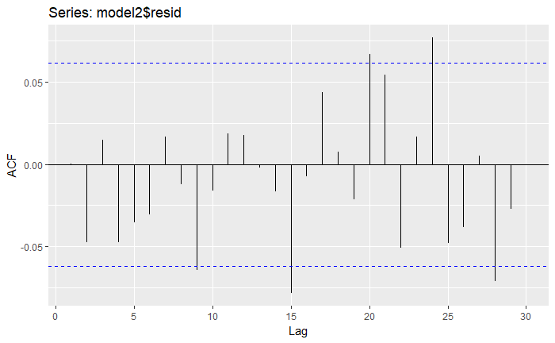

```r
autoplot(acf(model2$resid, plot = FALSE))
```

```r
model3=arima(x=sp500returns,order=c(1,1,1))
model3
```

```
Call:
arima(x = sp500returns, order = c(1, 1, 1))

Coefficients:
          ar1      ma1
      -0.0078  -1.0000
s.e.   0.0316   0.0033

sigma^2 estimated as 6.122e-05:  log likelihood = 3445.3,  aic = -6884.6
```

```r
Box.test(model3$resid,lag=10,type='Ljung')
```

```
    Box-Ljung test

data:  model3$resid
X-squared = 11.664, df = 10, p-value = 0.3082
```

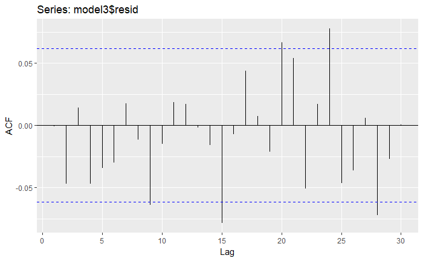

```r
autoplot(acf(model3$resid, plot = FALSE))
```

```r
model4=arima(x=sp500returns,order=c(1,0,1))
model4
```

```
Call:
arima(x = sp500returns, order = c(1, 0, 1))

Coefficients:
         ar1      ma1  intercept
      0.9423  -0.9724      4e-04
s.e.  0.0237   0.0160      1e-04

sigma^2 estimated as 6.066e-05:  log likelihood = 3456.7,  aic = -6905.41
```

```r
Box.test(model4$resid,lag=10,type='Ljung')
```

```
    Box-Ljung test

data:  model4$resid
X-squared = 6.8776, df = 10, p-value = 0.7369
```

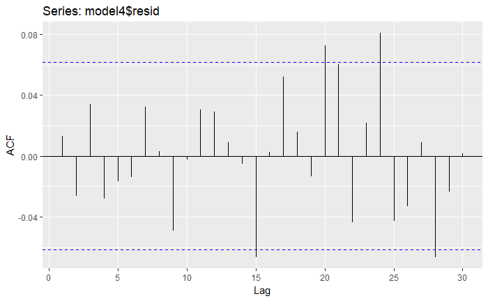

```r
autoplot(acf(model4$resid, plot = FALSE))
```

```r
model5=arima(x=sp500returns,order=c(2,1,2))
model5
```

```
Call:
arima(x = sp500returns, order = c(2, 1, 2))

Coefficients:
          ar1      ar2      ma1      ma2
      -0.6206  -0.0502  -0.3856  -0.6144
s.e.   0.2885   0.0334   0.2877   0.2877

sigma^2 estimated as 6.101e-05:  log likelihood = 3446.95,  aic = -6883.9
```

```r
Box.test(model5$resid,lag=10,type='Ljung')
```

```
    Box-Ljung test

data:  model5$resid
X-squared = 8.5656, df = 10, p-value = 0.5738
```

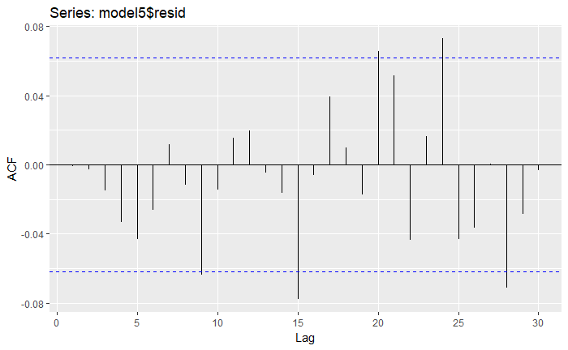

```r
autoplot(acf(model5$resid, plot = FALSE))
```

```r
model6=arima(x=sp500returns,order=c(3,0,2))
model6
```

```
Call:
arima(x = sp500returns, order = c(3, 0, 2))

Coefficients:
         ar1     ar2     ar3      ma1      ma2  intercept
      0.2311  0.6485  0.0223  -0.2465  -0.7069      4e-04
s.e.  0.2201  0.2214  0.0365   0.2179   0.2105      1e-04

sigma^2 estimated as 6.052e-05:  log likelihood = 3457.91,  aic = -6901.82
```

```r
Box.test(model6$resid,lag=10,type='Ljung')
```

```
    Box-Ljung test

data:  model6$resid
X-squared = 4.4465, df = 10, p-value = 0.925
```

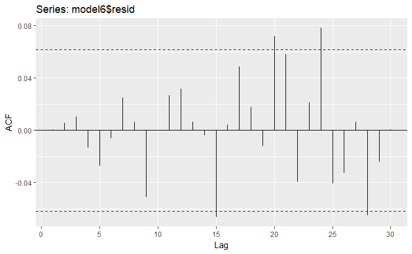

```r
autoplot(acf(model6$resid, plot = FALSE))
```

```r
model7=arima(x=sp500returns,order=c(3,0,3))
model7
```

```
Call:
arima(x = sp500returns, order = c(3, 0, 3))

Coefficients:
          ar1     ar2     ar3     ma1      ma2      ma3  intercept
      -0.3459  0.7003  0.4838  0.3324  -0.7633  -0.4918      4e-04
s.e.   2.9917  0.7493  1.9245  3.0323   0.7434   2.1427      1e-04

sigma^2 estimated as 6.049e-05:  log likelihood = 3458.09,  aic = -6900.17
```

```r
Box.test(model7$resid,lag=10,type='Ljung')
```

```
    Box-Ljung test

data:  model7$resid
X-squared = 4.1091, df = 10, p-value = 0.9423
```

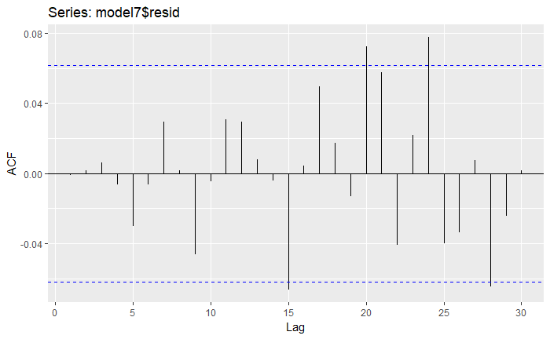

```r
autoplot(acf(model7$resid, plot = FALSE))
```

We select Model 4

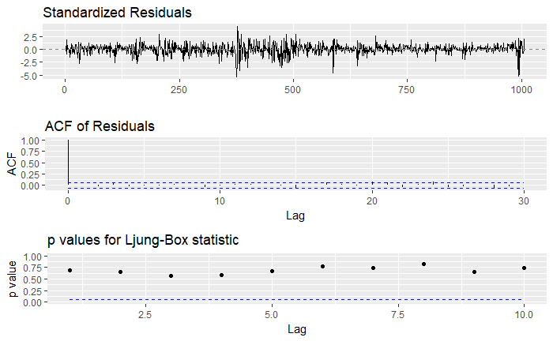

```r
ggtsdiag(model4)
```

```r
poly1=c(1,-model4$coef[1:3])
roots=polyroot(poly1)
roots
```

```
[1]    0.4844666+0.8911012i    0.4844666-0.8911012i 2320.4416551+0.0000000i
```

```r
Mod(roots)
```

```
[1]    1.014283    1.014283 2320.441655
```

```r
prediction = predict(model4, 10)
prediction
```

```
$pred
Time Series:
Start = 1007
End = 1016
Frequency = 1
 [1] 0.0001434447 0.0001593473 0.0001743318 0.0001884512 0.0002017555 0.0002142917 0.0002261041
 [8] 0.0002372346 0.0002477226 0.0002576050

$se
Time Series:
Start = 1007
End = 1016
Frequency = 1
 [1] 0.007788597 0.007792141 0.007795287 0.007798079 0.007800557 0.007802757 0.007804709 0.007806442
 [9] 0.007807981 0.007809346
```